# Text Mining and Analysis of the Novel *Little Women*

Sydney Rilum

2/19/2021

```r
# Read in pdf of "Little Women"
little_women_text <- pdf_text(here("data", "littlewomen.pdf"))
```

```r
# Convert text into a data frame
little_women_tidy <- data.frame(little_women_text) %>%
  mutate(text_full = str_split(little_women_text, pattern = '\\n')) %>%  # break pages up into individual lines
  unnest(text_full) %>%  # convert each line of text into one row
  mutate(text_full = str_trim(text_full)) %>%  # remove excess whitespace
  mutate(text_full = str_squish(text_full))

# Organize strings by chapter number
little_women_df <- little_women_tidy %>%
  slice(-(1:101)) %>%  # remove first rows containing preface and table of contents, start at Ch. 1
  mutate(chapter = case_when(
    str_detect(text_full, "CHAPTER") ~ text_full,  # detect rows containing the word "Chapter"
    TRUE ~ NA_character_
  )) %>%
  fill(chapter) %>%  # fill in Chapter # for each row in respective chapter
  separate(col = chapter, into = c("ch", "no"), sep = " ") %>%  # separate Chapter and # into two columns
  mutate(no = str_remove(no, pattern = "\\.")) %>%  # remove period after each Chapter#
  mutate(no = str_replace(no, pattern = "in", replacement = "III")) %>%  # fix error (XVIII was being read in as XVin)
  mutate(chapter = as.numeric(as.roman(no)))  # convert Ch# to be recognized as roman numerals and numeric class
```

```r
# Tokenization - wrangling words/tokens into tidy format
little_women_tokens <- little_women_df %>%
  unnest_tokens(word, text_full) %>%  # split a column into tokens (words) with one token per row
  dplyr::select(-little_women_text)  %>%  # remove little women text column
  anti_join(stop_words) %>%  # remove stop words (e.g. a, of, the, etc.)
  mutate(word = str_squish(word)) %>%
  filter(word != "jo") %>%  # remove character names
  filter(word != "jo's") %>%
  filter(word != "beth") %>%
  filter(word != "meg") %>%
  filter(word != "amy") %>%
  filter(word != "amy's") %>%
  filter(word != "march") %>%
  filter(word != "laurie") %>%
  filter(word != "john") %>%
  filter(word != "brooke") %>%
  filter(word != "hannah") %>%
  filter(word != "kate") %>%
  filter(word != "demi") %>%
  filter(word != "bhaer") %>%
  filter(word != "fred") %>%
  filter(word != "women") %>%
  filter(word != "chapter") %>%
  filter(word != "do") %>%  # remove misc. words
  filter(word != "n't") %>%
  filter(word != "11") %>%
  filter(word != "ve") %>%
  filter(word != "ing")
```

### Most Frequently Used Words in *Little Women*

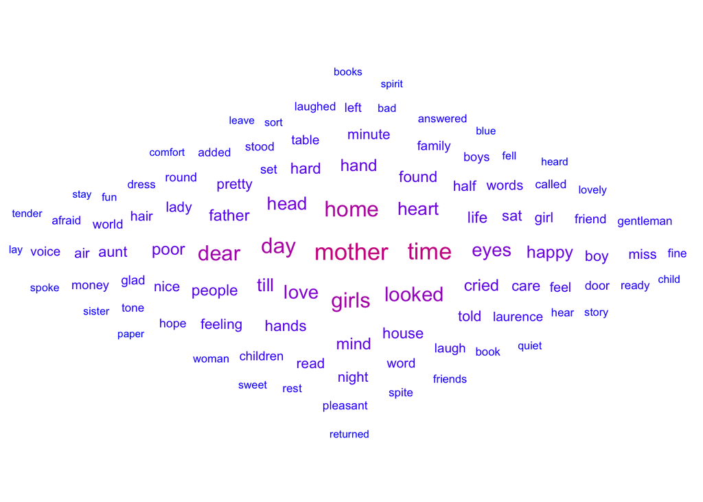

```r
# Get word counts
little_women_wordcount <- little_women_tokens %>%
  count(word)

# Make a word cloud using the top 100 words
top100 <- little_women_wordcount %>%
  arrange(-n) %>%  # arrange counts from largest to smallest
  slice(1:100)  # keep top 100 words

word_cloud <- ggplot(data = top100, aes(label = word)) +
  geom_text_wordcloud(aes(color = n, size = n), shape = "diamond") +
  scale_size_area(max_size = 6) +
  scale_color_gradientn(colors = c("blue","blueviolet","violetred")) +
  theme_minimal()

word_cloud
```

**Figure 1.** Wordcloud containing the top 100 most frequently used words in Louisa May Alcott’s *Little Women*. Character names and stop words, such as “is”, “of”, “the”, and “and”, were removed from word counts to allow for more interesting word assortment. (Data: Alcott 1916).

### Sentiment Analysis of *Little Women*

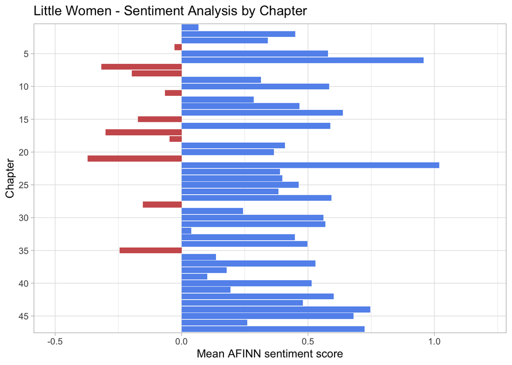

```r
# Get word counts by chapter
little_women_wordcount_ch <- little_women_tokens %>%
  count(chapter, word)

# Bind words in `little_women_wordcount` to the `afinn` lexicon
little_women_afinn <- little_women_wordcount_ch %>%
  inner_join(get_sentiments("afinn"))

# Find the mean AFINN score by chapter:
afinn_means <- little_women_afinn %>%
  group_by(chapter) %>%
  summarize(mean_afinn = mean(value)) %>%
  mutate(pos = mean_afinn >= 0) # create a new column that indicates + or - value

# Graph positivity and negativity of chapters
ggplot(data = afinn_means,
       aes(x = fct_rev(as.factor(chapter)),
           y = mean_afinn,
           fill = pos)) +
  geom_col(position = "identity") +
  scale_fill_manual(values = c("indianred", "cornflowerblue")) +
  scale_x_discrete(breaks = c(5, 10, 15, 20, 25, 30, 35, 40, 45)) +
  scale_y_continuous(limits = c(-0.5, 1.2)) +
  coord_flip() +
  theme_light() +
  labs(x = "Chapter",
       y = "Mean AFINN sentiment score",
       title = "Little Women - Sentiment Analysis by Chapter") +
  theme(legend.position = "none")
```

**Figure 2.** Column graph displaying mean AFINN scores for the words in Parts 1 and 2 (Chapters 1-47) of *Little Women*, using the AFINN lexicon. The AFINN lexicon ranks words from -5 (very negative sentiment) to +5 (very positive sentiment). Blue bars indicate chapters containing more words (on average) with positive mean sentiments, while red bars indicate chapters containing more words (on average) with negative mean sentiments. (Data: Alcott 1916, Nielson 2011).

#### Citations:

Text Data: [Alcott, Louisa M. *Little Women: or Meg, Jo, Beth, and Amy.* Little, Brown, and Company, 1916.](https://archive.org/details/littlewomen00alcoiala/page/n7/mode/2up)

Sentiment Lexicon: [Finn Årup Nielsen A new ANEW: Evaluation of a word list for sentiment analysis in microblogs. Proceedings of the ESWC2011 Workshop on ‘Making Sense of Microposts’: Big things come in small packages 718 in CEUR Workshop Proceedings 93-98. 2011 May.](http://arxiv.org/abs/1103.2903.)